# Module 6 - Instrumental Variables (Answer Key)

ECON 526/593E

# Instrumental Variables

*"Economic shocks in the fisheries sector and maritime piracy"*

**Click for Submission Instructions & Data**

Prepare your answers in R Markdown. Your submission should contain the exact same headings shown below along with your text and graphs, where appropriate, addressing all questions. When you knit your R Markdown script, use the following file naming convention for the html and Rmd documents you generate: lastname_module_N_homework.html (.Rmd) (replace "lastname" with your last name and "N" with the module number). Email your documents as attachments to ajc0056@mix.wvu.edu with the subject line "ECON 593 lastname Homework Module N". You can download the data for this module here. It will specify when/where packages are needed.

Instrumental variables (IV) represents an important causal inference method in applied economists' tool box. IV can be difficult to implement because it requires a special variable -- an instrument -- to work. One cannot just proclaim a variable an instrument like a magician pulling a rabbit out of a hat. Understanding why a variable constitutes a good instrument is key to IV and typically requires deep understanding of the underlying mechanisms. Good instruments often originate outside the primary data set. This homework focuses on such a case.

The paper that forms the basis for this homework analyzes the tradeoffs and opportunity costs in the oceanic commercial fishing industry using data from around the world. Commercial fishing requires boats, and boats can be used to fish or for other purposes, including piracy. Boat owners will use their vessel for the activity that generates the highest return. This informs the research question addressed in the paper: do reduced fishing conditions lead boat owners to turn to piracy?

Fisheries represent a classic economic common pool resource that can be plagued by overuse (economists call this the "tragedy of the commons"). Because of this, various extra-governmental agencies monitor commercial fishing activity, generating good data on commercial fish production by country. International trade depends heavily on oceanic transport, and piracy represents an important threat to the free flow of goods across countries, leading to systematic data collection on acts of piracy.

Despite these excellent data sources, a simple OLS regression where the dependent variable captures acts of piracy and the explanatory variable reflects commercial fishing activity cannot tell us much about the causal effect of commercial fishing returns on piracy.

## Question 1

Summarize the main research question in the paper, the application analyzed and why the IV approach is appropriate for this research question. (**2 Points**)

## Question 2

Read in the dataset for this homework and name it `pirates`. Describe the structure of this data set in terms of the cross sectional unit of analysis and time dimension. Generate commonly reported summary statistics for the dataset using the `stargazer` package. Discuss the main outcome variable `piracy`.

Install the `maps` package. Use this to plot a map of the world (hint[^1]) with all of the observations as points using latitude and longitude variables in `pirates`. Color the points by continent. (**2 points**)

```
##
## ========================================================================
## Statistic       N    Mean    St. Dev.   Min    Pctl(25) Pctl(75)   Max
## ------------------------------------------------------------------------
## country        636  443.307  248.933     2       230     651.2     950
## year           636 2,006.497  1.707    2,004    2,005    2,008    2,009
## piracy         636   0.225    0.418      0        0        0        1
## log_population 636  16.262    1.641    13.034   15.167   17.427  21.009
## log_plankton   636   5.316    1.629    -1.032   4.325    6.430   10.384
## log_fishcaught 636  10.124    2.695    0.000    8.377    11.897  16.022
## log_rain       636   6.595    1.059    2.448    6.244    7.380    8.173
## log_GDP        636   8.502    1.519    5.138    7.242    9.814   11.461
## latitutde      604  19.628    25.347  -37.810   5.330    38.410  60.470
## longitude      604  13.302    62.799  -123.130 -15.600   41.660  174.760
## ------------------------------------------------------------------------
```

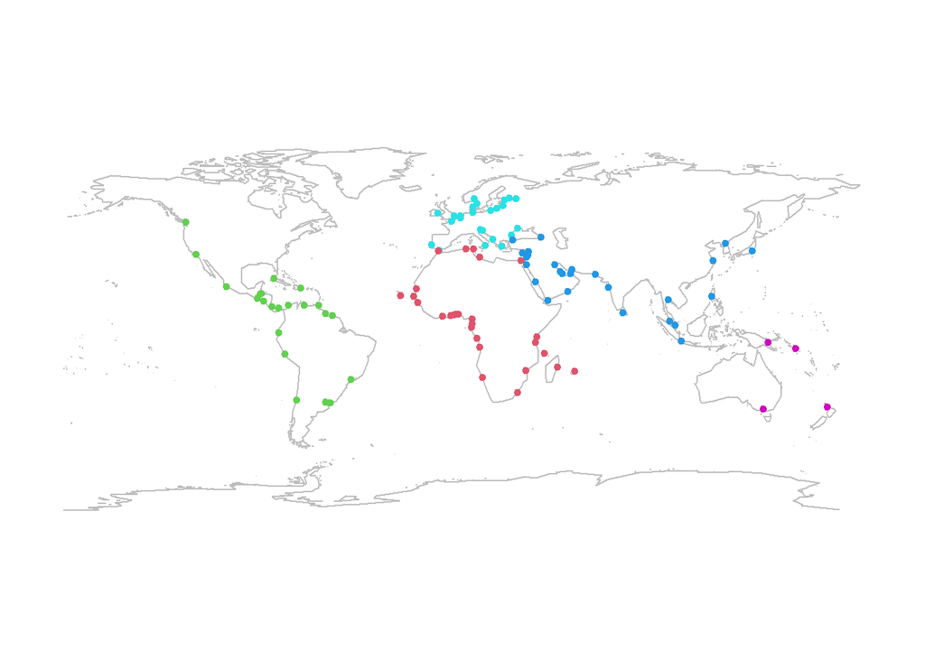

```r
library("stargazer")

pirates <- read.csv("https://alexcardazzi.github.io/teaching/econ-593e/pirates.csv", stringsAsFactors = FALSE)
stargazer(pirates, type = "text")

# install.packages("maps")
library("maps")

map("world", col = "grey", interior = FALSE)
continentz <- c("africa", "america", "asia", "europe", "oceania")
points(pirates$longitude, pirates$latitutde, pch = 20,
       col = 1 + match(pirates$continent, continentz))
```

## Question 3

Describe the causal inference method used in this paper. Discuss the assumptions underlying the causal inference method used in the empirical analysis. Discuss the instrument used in this analysis and the mechanism that makes this a good instrument. Include a discussion of threats to validity of the results in terms of the empirical setting. (**2 points**)

## Question 4

Plot the relationship between plankton and fish caught (hint[^2]). In the jargon of IV methods, this is called the *first stage* relationship. Color the points by continent and fix labels. Make sure to use a legend. Use the `scales` package to set the opacity to 40% and make the points solid circles. What sort of pattern(s) emerge in these data? Discuss why this relationship is important in terms of IV. (**2 points**)

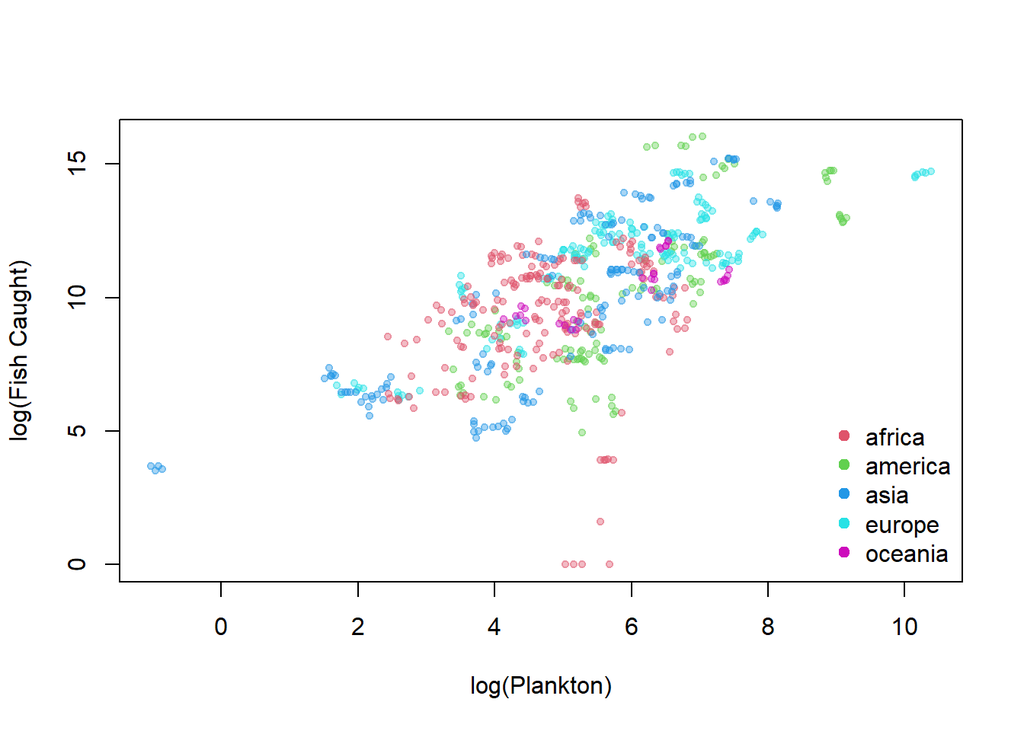

```r
library("scales")
par(mar=c(5.1, 4.1, 4.1, 2.1))
plot(pirates$log_plankton, pirates$log_fishcaught,
     col = alpha(1 + match(pirates$continent, continentz), .4),
     pch = 20,
     main = "", xlab = "log(Plankton)", ylab = "log(Fish Caught)")
legend("bottomright", legend = continentz,
       col = 2:6, pch = 19, bty = "n")
```

## Question 5

Replicate the main results reported in "Economic shocks in the fisheries sector and maritime piracy" based on the steps below. Make sure that you follow the guidelines for replicable research in your coding for this question. (**2 points**)

- Step 1: Replicate the OLS results reported in columns 3 and 7 on Table 2 of the paper. Do not worry about replicating the reported standard errors. Make sure to include country fixed effects in your regressions, but do not report them in your stargazer output.
- Step 2: Install (and load) the package `AER` (hint[^3]).
- Step 3: Estimate three regression models to replicate the IV results reported on Table 3 in the paper. The first regression model replicates results in column 1 on Table 3, a naive OLS regression model using the ivreg command in `AER` where piracy incidence is the dependent variable and log(fish catch) is the explanatory variable. The second regression model replicates results in column 2 on Table 3, the IV results, again using the ivreg command. The third regression model adds control variables for rain, GDP and population to the IV model. This model resembles the results in columns 4-6 on Table 3 in the paper. Display the results in using stargazer (omitting parameter estimates on the time trends and country fixed effects).

*Note that each of the regression models in Step 3 must include continent-specific time trends. Time trends capture factors that increase or decrease systematically over time, like population growth or global temperature. Think about how you can include a time trend into these regression models using a variable already included in `pirates`. Next, think about how you can allow this time trend to vary for different continents using the interaction operator (`:`) between a categorical variable and a continuous variable.(hint[^4])

- Step 4: Estimate the first stage underlying regression model 2 estimated in Step 3. Display the results using stargazer (omitting trends and factors). Perform an overall F-test for this model and discuss the strength of the instrument based on this test (hint[^5]).

```r
reg1 <- lm(log_fishcaught ~ log_plankton + as.factor(year) + as.factor(country), data = pirates)
reg2 <- lm(piracy ~ log_plankton + as.factor(year) + as.factor(country), data = pirates)
stargazer(reg1, reg2,
          type = "text", omit = "factor")
```

```
##
## ===========================================================
##                                    Dependent variable:
##                                ----------------------------
##                                 log_fishcaught    piracy
##                                      (1)            (2)
## -----------------------------------------------------------
## log_plankton                       0.397***      -0.336***
##                                    (0.119)        (0.101)
##
## Constant                          11.083***      3.012***
##                                    (1.073)        (0.914)
##
## -----------------------------------------------------------
## Observations                         636            636
## R2                                  0.988          0.645
## Adjusted R2                         0.986          0.567
## Residual Std. Error (df = 521)      0.323          0.275
## F Statistic (df = 114; 521)       384.125***     8.308***
## ===========================================================
## Note:                           *p<0.1; **p<0.05; ***p<0.01
```

```r
# install.packages("AER")
library("AER")
iv1 <- ivreg(piracy ~ log_fishcaught + as.factor(year) + as.factor(country)
             + continent:year
             , data = pirates)

iv2 <- ivreg(piracy ~ log_fishcaught + as.factor(year) + as.factor(country)
             + continent:year
             | log_plankton
             + as.factor(year) + as.factor(country)
             + continent:year
             , data = pirates)

iv3 <- ivreg(piracy ~ log_fishcaught + as.factor(year) + as.factor(country)
             + continent:year
             + log_rain + log_GDP + log_population
             | log_plankton
             + as.factor(year) + as.factor(country)
             + continent:year
             + log_rain + log_GDP + log_population
             , data = pirates)

stargazer(iv1, iv2, iv3, type = "text", omit = c("factor", "continent"))
```

```
##
## ======================================================================
##                                    Dependent variable:
##                     --------------------------------------------------
##                                           piracy
##                           (1)              (2)              (3)
## ----------------------------------------------------------------------
## log_fishcaught           -0.007          -0.967**         -1.008**
##                         (0.037)          (0.408)          (0.428)
##
## log_rain                                                   -0.090
##                                                           (0.135)
##
## log_GDP                                                   0.534**
##                                                           (0.230)
##
## log_population                                             -0.850
##                                                           (0.643)
##
## Constant                 52.329           62.229          132.075
##                         (66.315)        (100.033)        (107.254)
##
## ----------------------------------------------------------------------
## Observations              636              636              636
## R2                       0.639            0.180            0.163
## Adjusted R2              0.557            -0.007           -0.033
## Residual Std. Error 0.278 (df = 517) 0.419 (df = 517) 0.425 (df = 514)
## ======================================================================
## Note:                                      *p<0.1; **p<0.05; ***p<0.01
```

```r
stage1 <- lm(log_fishcaught ~ log_plankton
             + as.factor(year) + as.factor(country)
             + continent:year
             , data = pirates)
stargazer(stage1, type = "text", omit = c("factor", "continent"))
```

```
##
## ===============================================
##                         Dependent variable:
##                     ---------------------------
##                           log_fishcaught
## -----------------------------------------------
## log_plankton                 0.392***
##                               (0.123)
##
## Constant                      -4.336
##                              (77.288)
##
## -----------------------------------------------
## Observations                    636
## R2                             0.988
## Adjusted R2                    0.986
## Residual Std. Error      0.324 (df = 517)
## F Statistic         368.874*** (df = 118; 517)
## ===============================================
## Note:               *p<0.1; **p<0.05; ***p<0.01
```

```r
linearHypothesis(stage1, "log_plankton=0", type = c("f"), singular.ok = TRUE)
```

```
## Linear hypothesis test
##
## Hypothesis:
## log_plankton = 0
##
## Model 1: restricted model
## Model 2: log_fishcaught ~ log_plankton + as.factor(year) + as.factor(country) +
##     continent:year
##
##   Res.Df    RSS Df Sum of Sq      F   Pr(>F)
## 1    518 55.195
## 2    517 54.141  1    1.0537 10.062 0.001604 **
## ---
## Signif. codes:  0 '***' 0.001 '**' 0.01 '*' 0.05 '.' 0.1 ' ' 1
```

## Question 6

Discuss the results you generate. What is the interpretation of the causal parameter of interest in this case? Place the causal effect estimate in the context of the data. When interpreting the results, keep in mind that coefficients for logged and binary variables have nuanced interpretations (hint[^6]). (**2 points**)

## Question 7

Compare your results and this application to the example in the Mixtape chapter for this causal inference method. Is this application better or worse than the one in the chapter? How does this application, and these results, differ? For example, in terms of strength of assumptions, effect size, etc. (**2 points**)

## Question 8

Do you believe the results above are credibly causal? Are the sign and magnitude plausible? (**2 points**)

[figure not shown]

[^1]: Check out [this link](https://www.r-bloggers.com/2013/04/r-beginners-plotting-locations-on-to-a-world-map/)
[^2]: This should look like Figure 4 in the paper.
[^3]: [Resource](https://www.youtube.com/watch?v=YtVNvucdPqY).
[^4]: [Resource 1](https://www.econometrics-with-r.org/8-3-interactions-between-independent-variables.html), [Resource 2](https://stackoverflow.com/questions/34232834/fixed-effects-regression-with-state-specific-trends/51662203#51662203).
[^5]: [Resource](https://stats.stackexchange.com/questions/112442/what-are-aliased-coefficients#:~:text=If%20you%20have%20perfect%20multicollinearity,perfect%20multicollinearity%20in%20your%20regression).
[^6]: [Resource](http://www.cazaar.com/ta/econ113/interpreting-beta).